# Predicting the FIFA World Cup’s Winner Using Machine Learning

Nicolas Herrera

2022-12-07

[figure not shown]

# 1 Introduction

Using historical data of 7326 international football games, I estimated a series of machine learning models capable of predicting the outcome of football games (i.e., either one of the teams win or they tie). Then, I will use the best model to predict the outcomes of the 64 matches played during the Men’s Football World Cup currently played in Qatar (World Cup). By this moment, the round of 16 is being played and 20 teams have been eliminated.

## 1.1 Football 101 and the FIFA World Cup

Football (Association football or Soccer) is the most popular sport in the world. It is played by two teams of eleven people. The team that wins is the one that scores more goals by moving a round ball with their feet and scoring into a frame. The game is played for 90 minutes. The only possible outcomes of a match are either one of the teams wins or they draw.

The FIFA World Cup is an international competition played by national football teams. It is the most prestigious football tournament in the world. Although the first official football matches started in the 19th century, the first world cup was celebrated in 1930 and has been played every four years (except during WWII). Just eight different countries have won the cup. Brazil is at the top of the list with five titles won.

During the three years preceding the cup, there is a qualification phase to determine which teams qualify for the tournament. Within each continent, qualifying tournaments are held and just 32 teams end up playing in the World Cup. Between world cups, other continental tournaments and friendly matches are played. This project will use the matches prior to the world cup to estimate a model that is able to predict the outcome of a match and implement that estimation to predict the outcomes of the World Cup that is currently being played in Qatar. The following are the countries participating in the Cup:

[figure not shown]

In the first phase of the World cup, teams are divided into groups of four. They play three matches within their group. Winning a game is equivalent to three points, drawing to one point, and losing to zero points. The two teams with the most points within a group qualify for the next round of the tournament. Then, the 16 remaining teams enter the play-offs where a team is eliminated after losing a match in each round. The champion is the one that qualifies from the first phase and wins all the matches in the second phase. As no draws are allowed in the second phase, if two teams are tied at the end of the match, they play a series of penalty shoot-outs to determine the winner.

## 1.2 Roadmap of the project

To predict who will be the champion, first, we need to build a model that most accurately classifies the outcome of an individual game. Therefore, this project will use historical data from international soccer matches, team rankings and video game data, to predict the probability that either one of the teams win or tie. Then, I will estimate different classification models and assess which model better predicted the result of a game. The model that performs the best in the sample, will be used to predict the outcomes of the 64 games of the current world cup as a way to compare the accuracy of the model with a real-life situation.

# 2 Data Description and Cleaning

This section will describe the data sets used to build the model and display the code that cleans the data. First, I load the packages to be used throughout the project.

```r
# Load packages
library(tidyverse)
library(showtext)
library(janitor)
library(tidymodels)
library(lubridate)
library(fastDummies)
library(ggplot2)
library(zoo) # moving averages
library(readxl)
library(stringr)
library(viridis)
library(hrbrthemes)
library(gridExtra)
library(corrplot)
tidymodels_prefer()
library(summarytools)
library(vembedr)
library(ggridges)

# Vector of colors
colors_3 <- c("#1170AA", "#55AD89", "#EF6F6A")
colors <- c("#D33F49" , "#107E7D", "#EF6F6A"  ,"#65AFFF",  "#F6AE2D" , "#011936" , "#5B7B7A" , "#C7EFCF" , "#442B48")

# Personalized theme


theme_per <- function(base_size = 14) {
  theme_bw(base_size = base_size) %+replace%
    theme(
      # L'ensemble de la figure
      plot.title = element_text(size = rel(0.65), hjust = 0.5 , margin = margin(0,0,15,0) ),
      # Zone où se situe le graphique
      #panel.grid.minor = element_blank(),
      panel.border = element_blank(),
      # Les axes
      axis.title = element_text(size = rel(0.65)),
      axis.text = element_text(size = rel(0.65)),
      axis.line = element_line(color = "black", arrow = arrow(length = unit(0.3, "lines"), type = "closed")),
      # La légende
      legend.title = element_text(size = rel(0.65)),
      legend.text = element_text(size = rel(0.60)),
      legend.key = element_rect(fill = "transparent", colour = NA),
      legend.key.size = unit(1, "lines"),
      legend.background = element_rect(fill = "transparent", colour = NA),
      # Les étiquettes dans le cas d'un facetting
      strip.background = element_rect(fill = "#17252D", color = "#17252D"),
      strip.text = element_text(size = rel(0.85), face = "bold", color = "white", margin = margin(5,0,5,0))
    )
}
```

## 2.1 Raw Data

For this project I used three main data sources available at Kaglee:

- [**International football results from 1872 to 2022**](https://www.kaggle.com/datasets/martj42/international-football-results-from-1872-to-2017?select=results.csv): The dataset contains 44,104 results of international football matches starting from the very first official match in 1872 up to 2022. The sample covers any match before the current World Cup i.e any match before 2022-11-17. It includes tournaments, qualifier tournaments, FIFA World Cup, and friendly matches.

  This dataset has game-level information containing the name of the teams involved, the date of the match, the score, the tournament, and the place where the match was held. The following is an extract of the data showing the most recent games before the World Cup:

```r
# Importing the results *International football results from 1872 to 2022 and creating base variables
#-----------------------------------------------------------------------------------

results <- read_csv("data/results.csv") %>% # Load data
  clean_names() %>% # Clean the variable names
  mutate(date = as.Date(date, "%Y-%m-%d")) %>%  # Declare the dates in the correct format
  mutate(year=year(date) , month=month(date)) %>% # Create variables for year and month
  filter(!is.na(home_score) | !is.na(away_score)) %>% # Keep the games with results,removing games of the current WC
  mutate(home_result = factor(ifelse(home_score > away_score , "win" , # Creates two variables with the result of the match for home and away
                                     ifelse(home_score == away_score ,
                                            "draw" , "loss")))  ,
         away_result = factor(ifelse(home_score < away_score , "win" ,
                                     ifelse(home_score == away_score ,
                                            "draw" , "loss") )) ,
         across('home_team', str_replace , "Brunei Darussalam" ,"Brunei") , # Clean country names to match
         across('away_team', str_replace , "Brunei Darussalam" ,"Brunei")) %>%
  dummy_cols(select_columns = c('home_result' , 'away_result')) # Create dummies of each

# Overview main data
knitr::kable(results[44100:44104,1:9], format="markdown")
```

| date | home_team | away_team | home_score | away_score | tournament | city | country | neutral |
| --- | --- | --- | --- | --- | --- | --- | --- | --- |
| 2022-11-16 | Turkey | Scotland | 2 | 1 | Friendly | Diyarbakir | Turkey | FALSE |
| 2022-11-16 | United Arab Emirates | Argentina | 0 | 5 | Friendly | Abu Dhabi | United Arab Emirates | FALSE |
| 2022-11-16 | Uzbekistan | Kazakhstan | 2 | 0 | Friendly | Tashkent | Uzbekistan | FALSE |
| 2022-11-16 | Lithuania | Iceland | 0 | 0 | Baltic Cup | Kaunas | Lithuania | FALSE |
| 2022-11-16 | Latvia | Estonia | 1 | 1 | Baltic Cup | Riga | Latvia | FALSE |

- [**FIFA World Ranking 1992 - 2022**](https://www.kaggle.com/datasets/cashncarry/fifaworldranking): This dataset contains the [FIFA Ranking](https://www.fifa.com/fifa-world-ranking/men?dateId=id13792) for men’s national teams between 1992 to 2022. The ranking is a comparison of the relative strengths of the 211 nations associated with FIFA. It is widely used to organize tournaments. For instance, the 8 teams that are at the top of the list before a World Cup are placed in different groups for the first phase. FIFA computes points based on the Elo rating system and ranks teams based on the points earned previously.

  The calculation procedure of the points for the ranking has changed over time. Instead, I computed the average number of points awarded per country and year. Then, I create a standardized index with a value of 100 for the team with the highest average number of points during the year and 0 for the lowest. The difference between indexes is a measure of the difference in strength between two countries. The following is an extract of the data::

```r
# Fifa ranking
#-----------------------------------------------------------------------------------
fifa_ranking <- read_csv("data/fifa_ranking.csv") %>%
  clean_names() %>%
  mutate(date = as.Date(rank_date, "%Y-%m-%d") , year=year(date) ,
         across('country_full', str_replace , "Brunei Darussalam" ,"Brunei") ,
         across('country_full', str_replace , "Cabo Verde" ,"Cape Verde") ,
         across('country_full', str_replace , "Cape Verde Islands" ,"Cape Verde") ,
         across('country_full', str_replace , "Congo DR" ,"DR Congo") ,
         across('country_full', str_replace , "IR Iran" ,"Iran"),
         across('country_full', str_replace , "Côte d'Ivoire" ,"Ivory Coast"),
         across('country_full', str_replace , "Kyrgyz Republic" ,"Kyrgyzstan"),
         across('country_full', str_replace , "Korea DPR" ,"North Korea"),
         across('country_full', str_replace , "St. Kitts and Nevis" ,"Saint Kitts and Nevis"),
         across('country_full', str_replace , "St. Vincent / Grenadines" ,"Saint Vincent and the Grenadines"),
         across('country_full', str_replace , "St. Vincent and the Grenadines" ,"Saint Vincent and the Grenadines"),
         across('country_full', str_replace , "Korea Republic" ,"South Korea"),
         across('country_full', str_replace , "St. Vincent and the Grenadines" ,"Saint Vincent and the Grenadines"),
         across('country_full', str_replace , "USA" ,"United States"),
         across('country_full', str_replace , "US Virgin Islands" ,"United States Virgin Islands") ,
         across('country_full', str_replace , "FYR Macedonia" ,"North Macedonia")) %>%
  select(year , country_full, total_points) %>%
  group_by(country_full , year) %>%
  summarize(ranking_fifa = mean(total_points)) %>%
  ungroup() %>%
  group_by(year) %>%
  mutate( max = max(ranking_fifa) , min = min(ranking_fifa) ,
          ranking_fifa= (ranking_fifa - min)*100/(max - min)) %>%
  select(-max , -min) %>%
  ungroup()

# Overview main data
knitr::kable(fifa_ranking[240:246,1:3], format="markdown")
```

| country_full | year | ranking_fifa |
| --- | --- | --- |
| Argentina | 2020 | 85.260533 |
| Argentina | 2021 | 89.117524 |
| Argentina | 2022 | 93.892819 |
| Armenia | 1994 | 5.157438 |
| Armenia | 1995 | 14.501511 |
| Armenia | 1996 | 26.735598 |
| Armenia | 1997 | 37.226277 |

- [**FIFA 15 to 22 Videogame Player Datataset**](https://www.kaggle.com/datasets/stefanoleone992/fifa-22-complete-player-dataset) and [**FIFA 23 Videogame Player Datataset**](https://www.kaggle.com/datasets/sanjeetsinghnaik/fifa-23-players-dataset): This dataset contains player-level data from the series of FIFA video games released annually between 2015 and 2023 by EA Sports. This franchise has the Guinness World record as the best-selling sports video game franchise in the world. For each player in the game, there are a series of attributes that make the character perform as close as possible to the player in real life.

  This dataset contains characteristics of the player such as nationality, age, and market valuation. Additionally, as every player in the game is based on the real character’s performance during the season, each player has an overall score that summarizes his strength in the game. It is based on around 30 statistics including shooting, passing, pace, stamina, dribbling, and more (all scores are integers between 50 and 100).

  For international games, the coach of a team may call any national of the country who has not played with another national senior team in the past. As it is difficult to merge the exact squad per game to train the model, my overall team score will be the average overall score of the top 26 players by country and lagged year.

  Different than the FIFA ranking, the video game’s overall score for a team, measures the skills of the top players in the country and apriori it is a good candidate to predict the outcome of a match. Since 2010, [EA sports has simulated the World Cups using their game and has correctly predicted the last three winners](https://www.nbcsports.com/philadelphia/ea-sports-predicts-lionel-messi-argentina-2022-world-cup-champions).

  The code below creates a year-country measure of the strength of each national team based on the points awarded to each player in the video game. The overall score of the team is standardized to have a value of 100 for the highest observation per year and 0 for the lowest. The following table shows an extract of the data for the FIFA 23 game:

```r
# Fifa game datasets
#----------------------------------------------------------------------
# Function to read and summarize scores in fifa game by country
fifa_game <- function(y) {
  path_data <- paste0("data/players_",y,".csv")
  game_scores <- read_csv(path_data) %>%
    clean_names() %>%
    mutate(overall=(overall+potential)/2) %>%
    arrange(nationality_name , desc(overall)) %>%
    group_by(nationality_name) %>%
    mutate(ranking_player = seq_along(nationality_name)) %>%
    ungroup() %>%
    filter(ranking_player < 27) %>%
    mutate(year= y + 2000 - 1) %>%
    group_by(nationality_name , year) %>%
    summarize(overall = mean(overall) , npg=max(ranking_player)) %>%
    ungroup() %>%
    mutate(year=ifelse(nationality_name=="Bhutan",2019,year) ,
           across('nationality_name', str_replace , "Cape Verde Islands" ,"Cape Verde") ,
           across('nationality_name', str_replace , "Curacao" ,"Curaçao") ,
           across('nationality_name', str_replace , "Congo DR" ,"DR Congo") ,
           across('nationality_name', str_replace , "Guinea Bissau" ,"Guinea-Bissau") ,
           across('nationality_name', str_replace , "Guinea Bissau" ,"Guinea-Bissau") ,
           across('nationality_name', str_replace , "Côte d'Ivoire" ,"Ivory Coast") ,
           across('nationality_name', str_replace , "Korea DPR" ,"North Korea") ,
           across('nationality_name', str_replace , "Korea Republic" ,"South Korea"))
  return(game_scores)
}

# Create a list of datasets for each game
year_fifa <- c(15:23)
fifa_15_23 <- lapply(year_fifa, fifa_game)

# append them
fifa_game_scores <- bind_rows(fifa_15_23[1], fifa_15_23[2], fifa_15_23[3], fifa_15_23[4],
                              fifa_15_23[5], fifa_15_23[6], fifa_15_23[7], fifa_15_23[8],
                              fifa_15_23[9]) %>%
  group_by(year) %>%
  mutate(overall_max = max(overall) , overall_min = min(overall) ,
         overall= (overall - overall_min)*100/(overall_max - overall_min)) %>%
  select(-overall_min , -overall_max) %>%
  ungroup()

# Remove list of datasets
rm(fifa_15_23)

# Retrieve one part of the dataset and show the top of the data
fifa_23 <- read_csv("data/players_23.csv") %>%
  clean_names() %>%
  head() %>%
  mutate(value_in_euro = value_in_euro /1000000) %>%
  select(known_as , overall , value_in_euro , nationality_name , age , shooting_total, dribbling_total , passing_total)

knitr::kable(fifa_23[1:5,1:7], format="markdown")
```

| known_as | overall | value_in_euro | nationality_name | age | shooting_total | dribbling_total |
| --- | --- | --- | --- | --- | --- | --- |
| L. Messi | 91 | 54.0 | Argentina | 35 | 89 | 94 |
| K. Benzema | 91 | 64.0 | France | 34 | 88 | 87 |
| R. Lewandowski | 91 | 84.0 | Poland | 33 | 91 | 86 |
| K. De Bruyne | 91 | 107.5 | Belgium | 31 | 88 | 87 |
| K. Mbappé | 91 | 190.5 | France | 23 | 89 | 92 |

## 2.2 Data Cleaning

To estimate the models, I produced a unique dataset where each observation is a game. It includes the outcome of the game and features that predict the result such as the performance of each team in recent matches and tournaments, rankings, and video game scores. I restrict the information to games played since 2014 for two reasons. First, each FIFA video game is released in September of the previous year. The earliest data available corresponds to FIFA 15, released in September 2014. Second, because of the evolution of the sport, historically weaker nations have improved their performance in tournaments, the skills of a squad may not be entirely captured by historical data. Also, I will restrict the data to any match played by countries included in the ranking FIFA as they are the ones that can qualify for the tournament.

```r
# Database of the matches of the first round for the 2022 world cup
world_cup <- read_csv("data/results.csv") %>%
  clean_names() %>%
  filter(tournament == "FIFA World Cup" & country == "Qatar") %>%
  mutate(year=year(date))

# Countries playing current world cup
world_cup_countries <- as_tibble(world_cup$home_team) %>%
  bind_rows(as_tibble(world_cup$away_team)) %>%
  unique() %>%
  mutate(playing_wc = 1) %>%
  rename(team = value)

# Results for the entire history of the cups
results <- read_csv("data/results.csv") %>%
  clean_names() %>%
  mutate(date = as.Date(date, "%Y-%m-%d")) %>%
  mutate(year=year(date) , month=month(date)) %>%
  filter(!is.na(home_score) | !is.na(away_score)) %>%
  mutate(home_result = factor(ifelse(home_score > away_score , "win" ,
                                     ifelse(home_score == away_score ,
                                            "draw" , "loss")))  ,
         away_result = factor(ifelse(home_score < away_score , "win" ,
                                     ifelse(home_score == away_score ,
                                            "draw" , "loss") )) ,
         across('home_team', str_replace , "Brunei Darussalam" ,"Brunei") ,
         across('away_team', str_replace , "Brunei Darussalam" ,"Brunei")) %>%
  dummy_cols(select_columns = c('home_result' , 'away_result'))

# Include in the main database the FIFA game score
results <- results %>%
  left_join(fifa_game_scores , c("home_team" = "nationality_name" , "year")) %>%
  rename_at(vars(overall , npg),function(x) paste0(x,"_home")) %>%
  left_join(fifa_game_scores , c("away_team" = "nationality_name" , "year")) %>%
  rename_at(vars(overall , npg),function(x) paste0(x,"_away"))

# Include in the main database the FIFA ranking
results <- results %>%
  left_join(fifa_ranking , c("home_team" = "country_full" , "year")) %>%
  rename_at(vars(ranking_fifa),function(x) paste0(x,"_home")) %>%
  left_join(fifa_ranking , c("away_team" = "country_full" , "year")) %>%
  rename_at(vars(ranking_fifa),function(x) paste0(x,"_away"))

# Include in the main database and indicator of a match played by countries
# in the current WC

results <- results %>%
  left_join(world_cup_countries , c("home_team" = "team")) %>%
  left_join(world_cup_countries , c("away_team" = "team")) %>%
  mutate(playing_wc = if_else((playing_wc.x == 1 | playing_wc.y == 1),
                               1 , 0, missing = 0)) %>%
  select(-playing_wc.x  , -playing_wc.y)

# Results as list
#----------------------------------------------------------------------

# Create a dataset with information about home teams
results_home <- results %>%
  rename( team = home_team , goals_scored = home_score ,
          goals_received = away_score ,
          win = home_result_win ,
          draw = home_result_draw ,
          loss = home_result_loss ,
          ranking_fifa = ranking_fifa_home,
          ranking_fifa_opp = ranking_fifa_away ,
          overall = overall_home  ,
          overall_opp = overall_away ) %>%
  select(year , team , goals_scored , goals_received ,
         win, draw , loss , tournament , date , starts_with("ranking_fifa") ,
         starts_with("overall"))  %>%
  mutate(home = 1)

# Create a dataset with information about visiting teams
results_away <- results %>%
  rename( team = away_team , goals_scored = away_score ,
          goals_received = home_score ,
          win = away_result_win ,
          draw = away_result_draw ,
          loss = away_result_loss ,
          ranking_fifa = ranking_fifa_away,
          ranking_fifa_opp = ranking_fifa_home ,
          overall = overall_away  ,
          overall_opp = overall_home) %>%
  select(year , team , goals_scored , goals_received ,
           win, draw , loss , tournament , date , starts_with("ranking_fifa") ,
           starts_with("overall"))  %>%
  mutate(home = 0)

# Create a list of the countries that played the qualification phase to the WC
country_wc_qualifier <- results_home %>%
  bind_rows(results_away) %>%
  filter(year >2017 & tournament == "FIFA World Cup qualification") %>%
  select(team) %>%
  unique()

# Update the results to matches where both countries played the qualification phase of
# the current World Cup

results <- results %>%
  right_join(country_wc_qualifier , c("home_team" = "team"))  %>%
  right_join(country_wc_qualifier , c("away_team" = "team"))

# Create a list of results of countries that played the current phase of the WC
results_list <- results_home %>%  # home results
  bind_rows(results_away) %>% # append away results
  right_join(country_wc_qualifier) %>%
  mutate(points = win*3 + draw) %>%
  unique()
  rm(results_home , results_away) # remove from memory duplicate data

# List of tournaments
tournaments <- results_list %>%
  filter(year >2014) %>%
  select(tournament) %>%
  unique()

# Tournaments
#----------------------------------------------------------------------

# List of continental tournaments
continental_tournaments <- c("AFC Asian Cup" ,
                             "African Cup of Nations" ,
                             "UEFA Euro qualification" ,
                             "Gold Cup qualification" ,
                             "Copa América" ,
                             "African Cup of Nations qualification" ,
                             "Gold Cup" ,
                             "Oceania Nations Cup qualification" ,
                             "Oceania Nations Cup" ,
                             "UEFA Euro" ,
                             "Confederations Cup" ,
                             "UEFA Nations League" ,
                             "CONCACAF Nations League" ,
                             "FIFA World Cup" ,
                             "Confederations Cup")

# Historical results in a rolling window
#--------------------------------------------------------------------------

# Entire history
results_hist <- results_list %>%
  mutate( n = 1) %>%
  arrange(team , date) %>%
  group_by(team) %>%
  mutate(sh_win = cummean(win)) %>%
  select(team, date , sh_win)
```

```r
# Since FIFA Ranking exists and there are 32 teams in the WC (Ranking FIFA available)
results_hist_rf <- results_list %>%
  filter(year>=1994 & !is.na(ranking_fifa_opp)) %>%
  mutate( n = 1) %>%
  arrange(team , date) %>%
  group_by(team) %>%
  mutate(sh_win = cummean(win) ,
         sh_loss = cummean(loss) ,
         av_goal_sc = cummean(goals_scored) ,
         av_goal_rec = cummean(goals_received) ,
         av_rf_opp = cummean(ranking_fifa_opp)) %>%
  select(team, date , starts_with("sh_") ,
         starts_with("av_"))

# Rolling basis results
#----------------------------------------------------------------------

# All last matches
results_rolling <- results_list %>%
  arrange(team , date) %>%
  group_by(team) %>%
  mutate(match_number = seq_along(team)) %>%
  ungroup() %>%
  filter(!is.na(ranking_fifa_opp)) %>%
  mutate(m5_goals_sc = ifelse(match_number > 5 , rollmean(goals_scored, k = 5, fill = NA , align="right") , NA) ,
         m15_goals_sc = ifelse(match_number > 15 , rollmean(goals_scored, k = 15,
                                                            fill = NA , align="right") , NA) ,
         m5_goals_rec = ifelse(match_number > 5 , rollmean(goals_received, k = 5,
                                                           fill = NA , align="right") , NA) ,
         m15_goals_rec = ifelse(match_number > 15 , rollmean(goals_received,
                                                             k = 15, fill = NA , align="right") , NA) ,
         m5_sh_win = ifelse(match_number > 5 , rollmean(win, k = 5, fill = NA , align="right") , NA) ,
         m15_sh_win = ifelse(match_number > 15 , rollmean(win, k = 15, fill = NA , align="right") , NA) ,
         m5_sh_loss = ifelse(match_number > 5 , rollmean(loss, k = 5, fill = NA , align="right") , NA) ,
         m15_sh_loss= ifelse(match_number > 15 , rollmean(loss, k = 15, fill = NA , align="right") , NA) ,
         m5_rf_opp = ifelse(match_number > 5 , rollmean(ranking_fifa_opp, k = 5, fill = NA ,
                                                        align="right") , NA) ,
         m15_rf_opp = ifelse(match_number > 15 , rollmean(ranking_fifa_opp, k = 15, fill = NA ,
                                                        align="right") , NA) ,
        m30_goals_sc = ifelse(match_number > 30 , rollmean(goals_scored, k = 30, fill = NA , align="right") , NA),
        m30_goals_rec = ifelse(match_number > 30 , rollmean(goals_received, k = 30, fill = NA ,
                                                            align="right"),NA),
        m30_sh_win = ifelse(match_number > 30 , rollmean(win, k = 30, fill = NA , align="right") , NA) ,
        m30_sh_loss = ifelse(match_number > 30 , rollmean(loss, k = 30, fill = NA , align="right") , NA) ,
        m30_rf_opp = ifelse(match_number > 30 , rollmean(ranking_fifa_opp, k = 30, fill = NA ,
                                                        align="right") , NA)) %>%
  select(team, date , starts_with("m5") , starts_with("m15") , starts_with("m30"))

# Results in world cups
#----------------------------------------------------------------------

# Filter the matches played in the World Cups and create a rolling sum of the
# number of matches
results_wc <- results_list %>%
  filter(tournament == "FIFA World Cup") %>%
  mutate( n = 1) %>%
  group_by(team , year) %>%
  summarize( matches = sum(n)) %>%
  ungroup() %>%
  group_by(team) %>%  complete(year = seq(1930,2018)) %>%
  mutate(across(matches , ~replace_na(.,0))) %>%
  mutate(n_matches_wch = cumsum(matches),
         year = year +4) %>%
  select(-matches)

# Join with results
#----------------------------------------------------------------------

# Keep just information of the matches played since 2014
results <- results %>%
  filter(year >=2014) %>%
  filter(home_team !=away_team) %>%
  unique() %>%
  filter(!is.na(ranking_fifa_home)) %>%
  filter(!is.na(ranking_fifa_away))  # Remove games with countries outside ranking FIFA

# Join historical results
results <- results %>%
  left_join(results_hist ,by =c("home_team" = "team" , "date")) %>%
  rename_at(vars(sh_win),function(x) paste0(x,"_hist_home")) %>%
  left_join(results_hist , by =c("away_team" = "team" , "date")) %>%
  rename_at(vars(sh_win),function(x) paste0(x,"_hist_away"))

# Join historical results since Ranking FIFA exists
results <- results %>%
  left_join(results_hist_rf ,by =c("home_team" = "team" , "date")) %>%
  rename_at(vars(sh_win:av_rf_opp),function(x) paste0(x,"_hist_rf_home")) %>%
  left_join(results_hist_rf , by =c("away_team" = "team" , "date")) %>%
  rename_at(vars(sh_win:av_rf_opp),function(x) paste0(x,"_hist_rf_away"))

# Join rolling basis
results <- results %>%
  left_join(results_rolling , by =c("home_team" = "team" , "date")) %>%
  rename_at(vars(m5_goals_sc:m30_rf_opp),function(x) paste0(x,"_home")) %>%
  left_join(results_rolling , by =c("away_team" = "team" , "date")) %>%
  rename_at(vars(m5_goals_sc:m30_rf_opp),function(x) paste0(x,"_away"))

# Join results in World Cups
results <- results %>%
  left_join(results_wc , by =c("home_team" = "team" , "year")) %>%
  rename_at(vars(ends_with("_wch")),function(x) paste0(x,"_home")) %>%
  left_join(results_wc , by =c("away_team" = "team" , "year")) %>%
  rename_at(vars(ends_with("_wch")),function(x) paste0(x,"_away")) %>%
  mutate(across(n_matches_wch_home:n_matches_wch_away , ~replace_na(.,0)))

# Create a smaller dataset with the variables that will be used in the model
results <- results %>%
         mutate(ranking_fifa_dha = ranking_fifa_home - ranking_fifa_away ,
                overall_dha =  overall_home - overall_away  ,
                sh_win_hist_dha = sh_win_hist_home - sh_win_hist_away  ,
                sh_win_dha = sh_win_hist_rf_home - sh_win_hist_rf_away  ,
                sh_loss_dha = sh_loss_hist_rf_home - sh_loss_hist_rf_away  ,
                av_goal_sc_dha = av_goal_sc_hist_rf_home - av_goal_sc_hist_rf_away ,
                av_goal_rec_dha = av_goal_rec_hist_rf_home - av_goal_rec_hist_rf_away ,
                av_rf_opp_dha = av_rf_opp_hist_rf_home - av_rf_opp_hist_rf_away ,
                w_sh_win_dha = av_rf_opp_hist_rf_home*sh_win_hist_rf_home -
                  sh_win_hist_rf_away*av_rf_opp_hist_rf_away ,
                m5_sh_win_dha = m5_sh_win_home - m5_sh_win_away  ,
                w_m5_sh_win_dha = m5_sh_win_home*m5_rf_opp_home - m5_sh_win_away*m5_rf_opp_away  ,
                m5_sh_loss_dha = m5_sh_loss_home - m5_sh_loss_away  ,
                m5_goals_sc_dha = m5_goals_sc_home - m5_goals_sc_away ,
                m5_goals_rec_dha = m5_goals_rec_home - m5_goals_rec_away ,
                m5_rf_opp_dha = m5_rf_opp_home - m5_rf_opp_away ,
                m15_sh_win_dha = m15_sh_win_home - m15_sh_win_away  ,
                w_m15_sh_win_dha = m15_sh_win_home*m15_rf_opp_home -
                  m15_sh_win_away*m15_rf_opp_away  ,
                m15_sh_loss_dha = m15_sh_loss_home - m15_sh_loss_away  ,
                m15_goals_sc_dha = m15_goals_sc_home - m15_goals_sc_away ,
                m15_goals_rec_dha = m15_goals_rec_home - m15_goals_rec_away ,
                m15_rf_opp_dha = m15_rf_opp_home - m15_rf_opp_away ,
                 m30_sh_win_dha = m30_sh_win_home - m30_sh_win_away  ,
                w_m30_sh_win_dha = m30_sh_win_home*m30_rf_opp_home -
                  m30_sh_win_away*m30_rf_opp_away  ,
                m30_sh_loss_dha = m30_sh_loss_home - m30_sh_loss_away  ,
                m30_goals_sc_dha = m30_goals_sc_home - m30_goals_sc_away ,
                m30_goals_rec_dha = m30_goals_rec_home - m30_goals_rec_away ,
                m30_rf_opp_dha = m30_rf_opp_home - m30_rf_opp_away ,
                n_matches_wch_dha=n_matches_wch_home - n_matches_wch_away ,
                score_dha = home_score - away_score) %>%
  select(date , home_team , away_team , tournament , neutral , year, date , home_result , ends_with("_dha"))
```

```r
# Export cleaned dataset
write_csv(results, "data/results_cleaned.csv")
```

The model I have in mind predicts the result of a match by comparing the relative strength of two teams. Therefore, the features I used are measures of the difference between the two teams in several dimensions. The final dataset will contain the following variables[^1]:

### 2.2.1 Match variables

- `neutral` : The game was played in a neutral field i.e. neither team is hosting.
- `year` : Year that the game was played.
- `date`: Date of the game.
- `tournament:` Name of the tournament played or if the match is friendly.
- `home_team` : Name of the team playing a game in their country.
- `away_team` : Name of the team playing a game in a visiting country.
- `score_dha` : Home-Away difference in the goals scored during a match.
- `home_result` : Outcome of the match for the home team, either win, loss or draw.

### 2.2.2 Rankings :

- `overall_dha` : Home-Away difference in the mean score of the best 26 players in the FIFA video game for the year of the match. . Normalized to 100 for the team with the highest overall score 1st in a year.
- `ranking_fifa_dha` : Home-Away difference in the points used to create the Ranking FIFA. Normalized to 100 for the team ranked 1st during the year.

### 2.2.3 Historical :

- `sh_win_hist_dha` : Home-Away difference in the share of games won in any competition recorded up to the date.
- `n_matches_wch_dha` : Home-Away difference in the number of matches played in the previous World Cups.

### 2.2.4 Recent History (Since the creation of the Ranking FIFA in 1994):

- `sh_win_dha` : Home-Away difference in the share of matches won since 1994.
- `sh_loss_dha` : Home-Away difference in share of matches loss since 1994.
- `av_goal_sc_dha` : Home-Away difference in the average goals scored since 1994.
- `av_goal_rec_dha` : Home-Away difference in the average goals received since 1994.
- `av_rf_opp_dha`: Home-Away difference in average ranking FIFA of the teams faced by the country used to compute the previous statistics since 1994.

### 2.2.5 Results of the last 5 games played:

- `m5_sh_win_dha` : Home-Away difference in the share of matches won in the last five games.
- `m5_sh_loss_dha` : Home-Away difference in share of matches in the last five games.
- `m5_goals_sc_dha` : Home-Away difference in the average goals scored in the last five games.
- `m5_goals_rec_dha` : Home-Away difference in the average goals received in the last five games.
- `m5_rf_opp_dha` : Home-Away difference in average ranking FIFA of the teams faced by the country used to compute the previous statistics in the last five games.

### 2.2.6 Results of the last 15 games played:

- `m15_sh_win_dha` : Home-Away difference in the share of matches won in the last fifteen games.
- `m15_sh_loss_dha` : Home-Away difference in share of matches in the last fifteen games.
- `m15_goals_sc_dha` : Home-Away difference in the average goals scored in the last fifteen games.
- `m15_goals_rec_dha` : Home-Away difference in the average goals received in the last fifteen games.
- `m15_rf_opp_dha` : Home-Away difference in average ranking FIFA of the teams faced by the country used to compute the previous statistics in the last fifteen games.

### 2.2.7 Results of the last 30 games played:

- `m30_sh_win_dha` : Home-Away difference in the share of matches won in the last thirty games.
- `m30_sh_loss_dha` : Home-Away difference in share of matches in the last thirty games.
- `m30_goals_sc_dha` : Home-Away difference in the average goals scored in the last thirty games.
- `m30_goals_rec_dha` : Home-Away difference in the average goals received in the last thirty games.
- `m30_rf_opp_dha` : Home-Away difference in average ranking FIFA of the teams faced by the country used to compute the previous statistics in the last thirty games.

# 3 Exploratory Data Analysis

## 3.1 Summary statistics

The table below contains summary statistics of the variables in the dataset. We can observe the following:

- The observations are games played between 2014-01-01 and 2022-11-16.
- There is information of the games played by more than 200 national teams .
- Most of the games between international teams are friendly i.e. there are no points or prices involved. The second most played tournament are the qualifiers for the World Cup.
- Most of the games are played in either one of the countries involved.
- There is more likelihood that the home team wins. This is a very good predictor for the outcome of a match and I will discuss it below.
- The games are played between teams with different levels of relative strength. The average match has a close level of strength between teams using the FIFA ranking or the overall video game score but their standard deviations are large. I take into account that there are 1813 missing values for the overall score by predicting those missing values with the year and the difference in rankings.
- There is missing data in the moving statistics using 15 and 30 lagged matches. They correspond to countries that have been newly affiliated to FIFA more recently like Kosovo.

```r
# Read cleaned data
results <- read_csv("data/results_cleaned.csv")

# Print a summary table
print(dfSummary(results, graph.magnif = 0.75,
      valid.col = FALSE ,varnumbers = FALSE ,
      max.distinct.values = 5 , headings=FALSE ,
      graph.col =FALSE , ) , max.tbl.height = 600, method = 'render' )
```

| **Variable** | **Stats / Values** | **Freqs (% of Valid)** | **Missing** |
| --- | --- | --- | --- |
| date [Date] | min : 2014-01-01 med : 2018-06-20 max : 2022-11-16 range : 8y 10m 15d | 1235 distinct values | 0 (0.0%) |
| home_team [character] | 1. Mexico 2. United States 3. Qatar 4. Japan 5. France [ 200 others ] | 86 ( 1.2% ) 85 ( 1.2% ) 80 ( 1.1% ) 79 ( 1.1% ) 73 ( 1.0% ) 6923 ( 94.5% ) | 0 (0.0%) |
| away_team [character] | 1. Iceland 2. Uganda 3. Panama 4. Costa Rica 5. Chile [ 199 others ] | 70 ( 1.0% ) 67 ( 0.9% ) 65 ( 0.9% ) 64 ( 0.9% ) 61 ( 0.8% ) 6999 ( 95.5% ) | 0 (0.0%) |
| tournament [character] | 1. Friendly 2. FIFA World Cup qualificat 3. UEFA Euro qualification 4. African Cup of Nations qu 5. UEFA Nations League [ 45 others ] | 2389 ( 32.6% ) 1629 ( 22.2% ) 519 ( 7.1% ) 476 ( 6.5% ) 468 ( 6.4% ) 1845 ( 25.2% ) | 0 (0.0%) |
| neutral [logical] | 1. FALSE 2. TRUE | 5326 ( 72.7% ) 2000 ( 27.3% ) | 0 (0.0%) |
| year [numeric] | Mean (sd) : 2018 (2.6) min ≤ med ≤ max: 2014 ≤ 2018 ≤ 2022 IQR (CV) : 5 (0) | 9 distinct values | 0 (0.0%) |
| home_result [character] | 1. draw 2. loss 3. win | 1754 ( 23.9% ) 2070 ( 28.3% ) 3502 ( 47.8% ) | 0 (0.0%) |
| ranking_fifa_dha [numeric] | Mean (sd) : 2.3 (22.8) min ≤ med ≤ max: -100 ≤ 2.5 ≤ 100 IQR (CV) : 26.5 (10.1) | 6830 distinct values | 0 (0.0%) |
| overall_dha [numeric] | Mean (sd) : 2.7 (24.6) min ≤ med ≤ max: -95.8 ≤ 2.5 ≤ 98.8 IQR (CV) : 33 (9) | 4931 distinct values | 1813 (24.7%) |
| sh_win_hist_dha [numeric] | Mean (sd) : 0 (0.1) min ≤ med ≤ max: -0.6 ≤ 0 ≤ 0.6 IQR (CV) : 0.2 (10.6) | 7311 distinct values | 0 (0.0%) |
| sh_win_dha [numeric] | Mean (sd) : 0 (0.2) min ≤ med ≤ max: -0.6 ≤ 0 ≤ 0.6 IQR (CV) : 0.2 (9.3) | 7294 distinct values | 0 (0.0%) |
| sh_loss_dha [numeric] | Mean (sd) : 0 (0.2) min ≤ med ≤ max: -0.8 ≤ 0 ≤ 0.8 IQR (CV) : 0.2 (-10.4) | 7301 distinct values | 0 (0.0%) |
| av_goal_sc_dha [numeric] | Mean (sd) : 0 (0.5) min ≤ med ≤ max: -2.1 ≤ 0.1 ≤ 2.1 IQR (CV) : 0.6 (10.1) | 7306 distinct values | 0 (0.0%) |
| av_goal_rec_dha [numeric] | Mean (sd) : 0 (0.7) min ≤ med ≤ max: -5 ≤ 0 ≤ 5.3 IQR (CV) : 0.6 (-15.1) | 7312 distinct values | 0 (0.0%) |
| av_rf_opp_dha [numeric] | Mean (sd) : 1 (9.1) min ≤ med ≤ max: -41.3 ≤ 0.8 ≤ 38.9 IQR (CV) : 10.3 (9.5) | 7314 distinct values | 0 (0.0%) |
| w_sh_win_dha [numeric] | Mean (sd) : 1.1 (9.4) min ≤ med ≤ max: -36.8 ≤ 1.3 ≤ 36.8 IQR (CV) : 11.5 (8.2) | 7314 distinct values | 0 (0.0%) |
| m5_sh_win_dha [numeric] | Mean (sd) : 0.1 (0.4) min ≤ med ≤ max: -1 ≤ 0 ≤ 1 IQR (CV) : 0.6 (6.7) | 11 distinct values | 0 (0.0%) |
| w_m5_sh_win_dha [numeric] | Mean (sd) : 2.3 (16.3) min ≤ med ≤ max: -68 ≤ 1.8 ≤ 62.2 IQR (CV) : 18.9 (7.1) | 7239 distinct values | 0 (0.0%) |
| m5_sh_loss_dha [numeric] | Mean (sd) : -0.1 (0.4) min ≤ med ≤ max: -1 ≤ 0 ≤ 1 IQR (CV) : 0.6 (-7.3) | 11 distinct values | 0 (0.0%) |
| m5_goals_sc_dha [numeric] | Mean (sd) : 0.1 (1.1) min ≤ med ≤ max: -4.4 ≤ 0.2 ≤ 4.8 IQR (CV) : 1.4 (7.7) | 46 distinct values | 0 (0.0%) |
| m5_goals_rec_dha [numeric] | Mean (sd) : -0.1 (1.1) min ≤ med ≤ max: -6.4 ≤ -0.2 ≤ 6.2 IQR (CV) : 1.4 (-8) | 62 distinct values | 0 (0.0%) |
| m5_rf_opp_dha [numeric] | Mean (sd) : 0.1 (10.9) min ≤ med ≤ max: -47.9 ≤ 0 ≤ 56.3 IQR (CV) : 12.9 (182.7) | 7308 distinct values | 0 (0.0%) |
| m15_sh_win_dha [numeric] | Mean (sd) : 0 (0.2) min ≤ med ≤ max: -0.8 ≤ 0 ≤ 0.8 IQR (CV) : 0.3 (7.6) | 27 distinct values | 17 (0.2%) |
| w_m15_sh_win_dha [numeric] | Mean (sd) : 1.6 (11.9) min ≤ med ≤ max: -52.6 ≤ 1.3 ≤ 52.6 IQR (CV) : 13.1 (7.6) | 7297 distinct values | 17 (0.2%) |
| m15_sh_loss_dha [numeric] | Mean (sd) : 0 (0.3) min ≤ med ≤ max: -0.9 ≤ 0 ≤ 0.9 IQR (CV) : 0.3 (-9.2) | 30 distinct values | 17 (0.2%) |
| m15_goals_sc_dha [numeric] | Mean (sd) : 0.1 (0.7) min ≤ med ≤ max: -3.3 ≤ 0.1 ≤ 3.1 IQR (CV) : 0.9 (8) | 105 distinct values | 17 (0.2%) |
| m15_goals_rec_dha [numeric] | Mean (sd) : -0.1 (0.8) min ≤ med ≤ max: -4.7 ≤ -0.1 ≤ 4.5 IQR (CV) : 0.9 (-10.9) | 136 distinct values | 17 (0.2%) |
| m15_rf_opp_dha [numeric] | Mean (sd) : 0.6 (10.1) min ≤ med ≤ max: -45.3 ≤ 0.5 ≤ 52.3 IQR (CV) : 11.2 (17.5) | 7297 distinct values | 17 (0.2%) |
| m30_sh_win_dha [numeric] | Mean (sd) : 0 (0.2) min ≤ med ≤ max: -0.8 ≤ 0 ≤ 0.8 IQR (CV) : 0.3 (8.1) | 47 distinct values | 76 (1.0%) |
| w_m30_sh_win_dha [numeric] | Mean (sd) : 1.4 (10.5) min ≤ med ≤ max: -48.9 ≤ 1.2 ≤ 47.9 IQR (CV) : 11.3 (7.7) | 7238 distinct values | 76 (1.0%) |
| m30_sh_loss_dha [numeric] | Mean (sd) : 0 (0.2) min ≤ med ≤ max: -0.9 ≤ 0 ≤ 0.9 IQR (CV) : 0.3 (-9.7) | 58 distinct values | 76 (1.0%) |
| m30_goals_sc_dha [numeric] | Mean (sd) : 0.1 (0.6) min ≤ med ≤ max: -2.6 ≤ 0.1 ≤ 2.7 IQR (CV) : 0.8 (8.6) | 164 distinct values | 76 (1.0%) |
| m30_goals_rec_dha [numeric] | Mean (sd) : -0.1 (0.7) min ≤ med ≤ max: -4 ≤ -0.1 ≤ 4 IQR (CV) : 0.7 (-11.8) | 248 distinct values | 76 (1.0%) |
| m30_rf_opp_dha [numeric] | Mean (sd) : 0.8 (9.9) min ≤ med ≤ max: -44.6 ≤ 0.7 ≤ 47.8 IQR (CV) : 10.9 (12.1) | 7238 distinct values | 76 (1.0%) |
| n_matches_wch_dha [numeric] | Mean (sd) : 2.5 (23.1) min ≤ med ≤ max: -109 ≤ 0 ≤ 106 IQR (CV) : 10 (9.3) | 191 distinct values | 0 (0.0%) |
| score_dha [numeric] | Mean (sd) : 0.5 (2.1) min ≤ med ≤ max: -11 ≤ 0 ≤ 15 IQR (CV) : 3 (4.3) | 26 distinct values | 0 (0.0%) |

Generated by summarytools 1.0.1 ([R](https://www.r-project.org/) version 4.2.1)  
2022-12-07

### 3.1.1 Correlation between predictors

The following graph shows the correlation between the variables that will be used in the model and the outcome. As expected, we can observe that the FIFA ranking and the overall score indexes have a positive linear relationship with the share of winnings. Historical information also has predictive power. The differences in the share of matches won historically and the number of matches played in all world cups have a coefficient of correlation of 0.35 and 0.30, respectively. The share of winnings/losses and average goals scored/received for different periods of time are positively/negatively related to the proportion of winnings. However, more recent games’ results have a higher correlation coefficient (in absolute value) for all these measures. Teams that have played against stronger[^2] in the past are also have a higher probability of winning.

Given that most of the matches are friendlies and qualifiers, teams play with neighbors most of the time. Historically, stronger teams have been in Europe or South America. To take into account the strength of the teams in the computation of differences in predictors, I created a series of differences weighted by the strength of the opponent. For instance, w_sh_win is the difference between the shares of winnings between teams with each share multiplied by the average strength of the teams they faced. The weighted wins I included have a larger correlation coefficient for most of the measures.

The results using the difference in shares of losses are the opposite of the winnings. However, predicting the draws seems more difficult as a close to zero difference should classify a result as a draw.

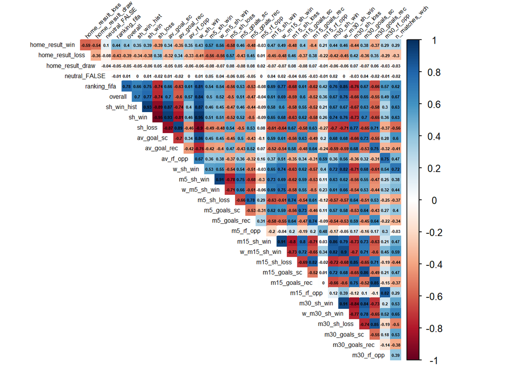

```r
# Create a correlation plot of the predictors and
results %>%
  dummy_cols(select_columns = c('home_result' , 'neutral')) %>%
  select(home_result_win, home_result_loss , home_result_draw , neutral_FALSE , ends_with("_dha")) %>%
  select(-score_dha) %>%
  drop_na() %>%
  rename_at(.vars = vars(ends_with("_dha")),
            .funs = funs(sub("[_]dha$", "", .))) %>%
  cor() %>%
  corrplot(method = 'color', diag = FALSE, type = 'upper',
          pch.cex = 0.9 , tl.col="black", tl.srt=45 , tl.cex = 0.5 , addCoef.col = "black" , number.cex = 0.35 )
```

## 3.2 Home Advantage

Playing at home is a huge advantage because of the attendance of supporters (Cross and Uhrig, 2023). A team is declared a “Home Team” if the game is played in its country. Home teams in neutral locations do not seem to have a systematic relationship with the hosting country[^3]. 72.7% of the games in the sample are played in one of the team’s countries. The games played on a neutral ground correspond, in general, to friendly matches or tournaments such as the World Cup.

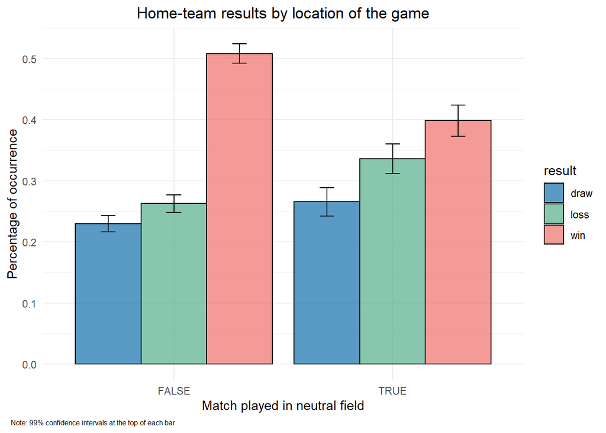

```r
# Save critical value of 1% level
z<-qnorm(0.01, mean = 0, sd = 1, lower.tail = FALSE)

# Create a bar graph comparing the percentage of the outcomes occurred per game
# divided by the location of the match
results %>%
  dummy_cols(select_columns = c('home_result')) %>%
  group_by(neutral) %>%
  summarize(matches=n() ,
            win = mean(home_result_win) ,
            loss = mean(home_result_loss) ,
            draw = mean(home_result_draw)) %>%
  gather(result, percentage, win,loss,draw) %>% # Reshape the data to have unique columns
  mutate(me = sqrt(percentage*(1-percentage)/matches)*z) %>% # Compute the margin of error per share
  ggplot(aes(fill=result, y=percentage, x=neutral) ) +
  geom_bar(position='dodge', stat='identity', colour="black" , alpha=0.7 ) +
  labs(title="Home-team results by location of the game",
       y="Percentage of occurrence" , x="Match played in neutral field" ,
       caption = "Note: 99% confidence intervals at the top of each bar") +
  theme_minimal() +
  scale_fill_manual(values = colors_3) +
  geom_errorbar( aes(x=neutral, ymin=percentage-me, ymax=percentage+me),
                 width=0.2, colour="black", position=position_dodge(.9)) + theme(plot.caption=element_text(hjust = -0.1 , size=6)) + theme(plot.title = element_text(hjust = 0.5))
```

```r
# Include 99% CI

# Saving as PNG
#png(file="images/bar_neutral.png", width=800, height=600)
#bar_neutral
#dev.off()
```